# Regression Analysis in QSAR

## Objective

1. To develop a function that relates descriptors to toxicity.
2. To compare relative importance of QuickProp descriptors on toxicity prediction.

## Outline

In this experiment, regression models relating QuickProp descriptors to predict toxicity are built from a data set consists of 322 compounds that were experimentally assessed.

## Require packages

```r
start <- function(pkg){
  npkg <- pkg[!(pkg %in% installed.packages()[,"Package"])]
  if (length(npkg))
    install.packages(npkg, dependencies = TRUE)
  lapply(pkg, require, character.only=TRUE)
}

pkgs <- c("QSARdata", "caret",'ggplot2')
start(pkgs)
```

```
## [[1]]
## [1] TRUE
##
## [[2]]
## [1] TRUE
##
## [[3]]
## [1] TRUE
```

## Load data

```r
data(AquaticTox)
head(AquaticTox_Outcome)
```

```
##                                             Molecule Activity
## 1                                       (d)-limonene     5.29
## 2 111-trichloro-2-methyl-2-propanolol(chlorobytanol)     3.12
## 3                                111-trichloroethane     3.40
## 4                             1122-tetrachloroethane     3.92
## 5                                112-trichloroethane     3.21
## 6                     11-dichloroethylene(vinylidene     2.84
```

```r
descriptors<-AquaticTox_QuickProp
data<-cbind(descriptors,AquaticTox_Outcome$Activity)
str(data)
```

```
## 'data.frame':    322 obs. of  51 variables:
##  $ Molecule                          : Factor w/ 320 levels "(d)-limonene",..: 1 31 32 34 33 30 42 40 41 45 ...
##  $ QikProp_.stars                    : int  7 6 12 11 12 12 7 7 11 8 ...
##  $ QikProp_.amine                    : int  0 0 0 0 0 0 0 0 0 0 ...
##  $ QikProp_.acid                     : int  0 0 0 0 0 0 0 0 0 0 ...
##  $ QikProp_.amide                    : int  0 0 0 0 0 0 0 0 0 0 ...
##  $ QikProp_.rotor                    : int  1 1 0 0 0 0 0 0 0 0 ...
##  $ QikProp_.rtvFG                    : int  0 0 0 0 0 0 0 0 1 0 ...
##  $ QikProp_CNS                       : int  2 2 1 1 1 1 1 1 1 1 ...
##  $ QikProp_mol_MW                    : num  136 177 133 168 133 ...
##  $ QikProp_dipole                    : num  0.436 3.953 2.475 3.058 3.978 ...
##  $ QikProp_SASA                      : num  382 317 271 290 270 ...
##  $ QikProp_FOSA                      : num  316.5 125.8 80.3 46.3 79.9 ...
##  $ QikProp_FISA                      : num  0 35.7 0 0 0 ...
##  $ QikProp_PISA                      : num  65.3 0 0 0 0 ...
```

[output cut: 37 more lines]

```r
colnames(data)[51]<- "Activity"
colSums(is.na(data))/nrow(data)
```

```
##                           Molecule                     QikProp_.stars
##                         0.00000000                         0.00931677
##                     QikProp_.amine                      QikProp_.acid
##                         0.00931677                         0.00931677
##                     QikProp_.amide                     QikProp_.rotor
##                         0.00931677                         0.00931677
##                     QikProp_.rtvFG                        QikProp_CNS
##                         0.00931677                         0.00931677
##                     QikProp_mol_MW                     QikProp_dipole
##                         0.00931677                         0.00931677
##                       QikProp_SASA                       QikProp_FOSA
##                         0.00931677                         0.00931677
##                       QikProp_FISA                       QikProp_PISA
##                         0.00931677                         0.00931677
##                       QikProp_WPSA                     QikProp_volume
##                         0.00931677                         0.00931677
##                    QikProp_donorHB                    QikProp_accptHB
##                         0.00931677                         0.00931677
##                    QikProp_dip.2.V                QikProp_ACxDN..5.SA
##                         0.00931677                         0.00931677
##                       QikProp_glob                    QikProp_QPpolrz
##                         0.00931677                         0.00931677
##                  QikProp_QPlogPC16                  QikProp_QPlogPoct
##                         0.00931677                         0.00931677
##                    QikProp_QPlogPw                  QikProp_QPlogPo.w
##                         0.00931677                         0.00931677
##                     QikProp_QPlogS                   QikProp_CIQPlogS
##                         0.00931677                         0.00931677
##                  QikProp_QPlogHERG                    QikProp_QPPCaco
##                         0.00931677                         0.00931677
##                    QikProp_QPlogBB                    QikProp_QPPMDCK
##                         0.00931677                         0.00931677
##                    QikProp_QPlogKp                     QikProp_IP.eV.
##                         0.00931677                         0.00931677
##                     QikProp_EA.eV.                     QikProp_.metab
##                         0.00931677                         0.00931677
##                  QikProp_QPlogKhsa        QikProp_HumanOralAbsorption
##                         0.00931677                         0.00931677
## QikProp_PercentHumanOralAbsorption                 QikProp_SAfluorine
##                         0.00931677                         0.00931677
##                   QikProp_SAamideO                        QikProp_PSA
##                         0.00931677                         0.00931677
##                     QikProp_.NandO                 QikProp_RuleOfFive
##                         0.00931677                         0.00931677
##                 QikProp_.ringatoms                      QikProp_.in56
##                         0.00931677                         0.00931677
##                    QikProp_.noncon                   QikProp_.nonHatm
##                         0.00931677                         0.00931677
##                QikProp_RuleOfThree        QikProp_ACxDN..5.SAxSASA.MW
##                         0.00931677                         0.00931677
##                           Activity
##                         0.00000000
```

The outcome is the negative log of activity labeled as “Activity”.

Missing values in each column can be ignored.

## Cleaning

```r
data<-na.omit(data)

descs <- data[, !apply(data, 2, function(x) any(is.na(x)) )]

descs <- descs[, !apply( descs, 2, function(x) length(unique(x)) == 1 )]

r2 <- which(cor(descs[2:50])^2 > .29, arr.ind=TRUE)

r2 <- r2[ r2[,1] > r2[,2] , ]
d <- descs[, -unique(r2[,2])]
```

## Preprocessing

Box-Cox transformation was performed on each column for better normality.

Dataset was split into training and test sets on a ratio of 8:2.

```r
Tran <- preProcess(d[,-1],method = "BoxCox")
data <-predict(Tran,d[,-1])

set.seed(909)
ind<-sample(2,nrow(data),replace=TRUE,prob=c(0.8,0.2))
training<-data[ind==1,-1]
training$ID <- seq.int(nrow(training))
test<-data[ind==2,-1]
```

## Linear least squares

Starting from a simple regression model.

```r
lm.fit <- lm(Activity ~ ., data = training[,-13])
summary(lm.fit)
```

```
##
## Call:
## lm(formula = Activity ~ ., data = training[, -13])
##
## Residuals:
##      Min       1Q   Median       3Q      Max
## -1.94521 -0.34591 -0.03278  0.30608  2.89760
##
## Coefficients:
##                                      Estimate Std. Error t value Pr(>|t|)
## (Intercept)                         8.765e-01  4.949e-01   1.771  0.07782
## QikProp_accptHB                    -4.594e-01  9.078e-02  -5.061 8.34e-07
## QikProp_EA.eV.                      3.052e-01  5.102e-02   5.981 8.01e-09
## QikProp_PercentHumanOralAbsorption -7.354e-05  1.064e-04  -0.691  0.49001
## QikProp_SAfluorine                 -6.059e-03  2.356e-03  -2.572  0.01071
## QikProp_PSA                         1.681e-02  6.826e-03   2.463  0.01450
## QikProp_.NandO                     -3.641e-01  1.399e-01  -2.603  0.00982
## QikProp_.in56                      -1.070e-01  1.890e-02  -5.660 4.32e-08
## QikProp_.noncon                     5.547e-02  5.505e-02   1.008  0.31459
## QikProp_.nonHatm                    1.310e+00  8.264e-02  15.850  < 2e-16
## QikProp_RuleOfThree                -8.072e-01  7.471e-01  -1.080  0.28103
## QikProp_ACxDN..5.SAxSASA.MW         2.971e+00  4.959e+00   0.599  0.54957
##
## (Intercept)                        .
## QikProp_accptHB                    ***
## QikProp_EA.eV.                     ***
## QikProp_PercentHumanOralAbsorption
## QikProp_SAfluorine                 *
## QikProp_PSA                        *
## QikProp_.NandO                     **
## QikProp_.in56                      ***
## QikProp_.noncon
## QikProp_.nonHatm                   ***
## QikProp_RuleOfThree
## QikProp_ACxDN..5.SAxSASA.MW
## ---
## Signif. codes:  0 '***' 0.001 '**' 0.01 '*' 0.05 '.' 0.1 ' ' 1
##
## Residual standard error: 0.6967 on 239 degrees of freedom
## Multiple R-squared:  0.7283, Adjusted R-squared:  0.7158
## F-statistic: 58.24 on 11 and 239 DF,  p-value: < 2.2e-16
```

```r
names(lm.fit)
```

```
##  [1] "coefficients"  "residuals"     "effects"       "rank"
##  [5] "fitted.values" "assign"        "qr"            "df.residual"
##  [9] "xlevels"       "call"          "terms"         "model"
```

```r
coef(lm.fit)
```

```
##                        (Intercept)                    QikProp_accptHB
##                       0.8765159293                      -0.4593854929
##                     QikProp_EA.eV. QikProp_PercentHumanOralAbsorption
##                       0.3051614092                      -0.0000735434
##                 QikProp_SAfluorine                        QikProp_PSA
##                      -0.0060594938                       0.0168111569
##                     QikProp_.NandO                      QikProp_.in56
##                      -0.3641379505                      -0.1069772166
##                    QikProp_.noncon                   QikProp_.nonHatm
##                       0.0554739717                       1.3098810193
##                QikProp_RuleOfThree        QikProp_ACxDN..5.SAxSASA.MW
##                      -0.8072460767                       2.9713774773
```

```r
confint(lm.fit)
```

```
##                                            2.5 %        97.5 %
## (Intercept)                        -0.0984261421  1.8514580007
## QikProp_accptHB                    -0.6382127931 -0.2805581928
## QikProp_EA.eV.                      0.2046594114  0.4056634069
## QikProp_PercentHumanOralAbsorption -0.0002830943  0.0001360075
## QikProp_SAfluorine                 -0.0107000084 -0.0014189792
## QikProp_PSA                         0.0033637973  0.0302585166
## QikProp_.NandO                     -0.6397189039 -0.0885569972
## QikProp_.in56                      -0.1442102849 -0.0697441483
## QikProp_.noncon                    -0.0529658474  0.1639137909
## QikProp_.nonHatm                    1.1470806464  1.4726813922
## QikProp_RuleOfThree                -2.2790703791  0.6645782257
## QikProp_ACxDN..5.SAxSASA.MW        -6.7965830552 12.7393380098
```

### Significance testing

When testing an hypothesis with a categorical explanatory variable and a quantitative response variable, the tool normally used in statistics is Analysis of Variances, also called ANOVA.

```r
anova(lm.fit)
```

```
## Analysis of Variance Table
##
## Response: Activity
##                                     Df  Sum Sq Mean Sq  F value    Pr(>F)
## QikProp_accptHB                      1  35.404  35.404  72.9424 1.580e-15
## QikProp_EA.eV.                       1  93.743  93.743 193.1374 < 2.2e-16
## QikProp_PercentHumanOralAbsorption   1  19.237  19.237  39.6340 1.454e-09
## QikProp_SAfluorine                   1   0.540   0.540   1.1116   0.29281
## QikProp_PSA                          1  36.442  36.442  75.0802 6.913e-16
## QikProp_.NandO                       1   1.674   1.674   3.4488   0.06453
## QikProp_.in56                        1   1.541   1.541   3.1746   0.07606
## QikProp_.noncon                      1   0.074   0.074   0.1516   0.69735
## QikProp_.nonHatm                     1 121.538 121.538 250.4033 < 2.2e-16
## QikProp_RuleOfThree                  1   0.572   0.572   1.1795   0.27856
## QikProp_ACxDN..5.SAxSASA.MW          1   0.174   0.174   0.3591   0.54957
## Residuals                          239 116.004   0.485
##
## QikProp_accptHB                    ***
## QikProp_EA.eV.                     ***
## QikProp_PercentHumanOralAbsorption ***
## QikProp_SAfluorine
## QikProp_PSA                        ***
## QikProp_.NandO                     .
## QikProp_.in56                      .
## QikProp_.noncon
## QikProp_.nonHatm                   ***
## QikProp_RuleOfThree
## QikProp_ACxDN..5.SAxSASA.MW
## Residuals
## ---
## Signif. codes:  0 '***' 0.001 '**' 0.01 '*' 0.05 '.' 0.1 ' ' 1
```

The first line tells us that adding a variable “QikProp_accptHB” is useful compared to a model with only an intercept because this single coefficient reduces the sum of squares by 35.404.

The original sum of squares of the model with just an intercept is:

```r
mu1 <- mean(training$Activity)
initss<- sum((training$Activity-mu1)^2)
initss
```

```
## [1] 426.9428
```

In the ANOVA table, each row considers the reduction in the sum of squared residuals after adding coefficients compared to the model in the previous row.

The first column “DF” shows the “degrees of freedom” with each row. As the “QikProp_accptHB” variable introduced only one term to the model, DF value is 1.

The column “F value” indicates the mean of squares for the inclusion of the terms of interest (the sum of squares divided by the degrees of freedom) divided by the mean squared residuals (from the bottom row).

**Null Hypothesis** The true value of the additional coefficient is 0.

**Alternative Hypothesis** There is an effect from the chemiscal substructure on biological activity.

A p-values smaller than 0.05 (as suggested by normal scientific standard) indicates stronger evidence against the null hypothesis and thus we accept the alternative hypothesis.

### Residual plots:

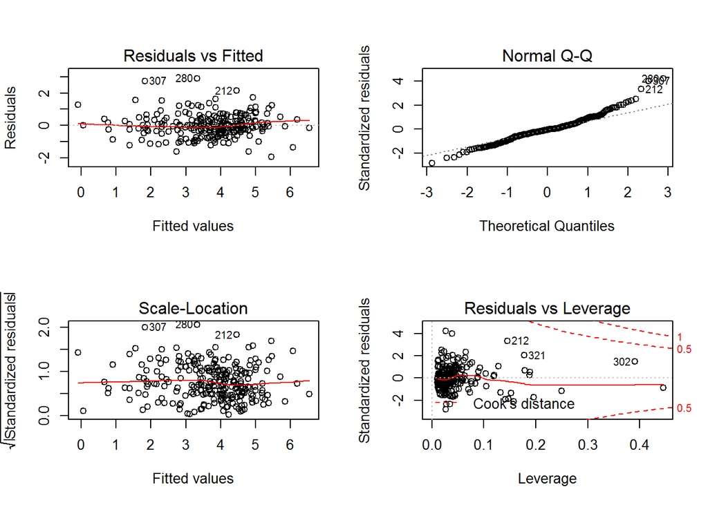

```r
par(mfrow = c(2,2))
plot(lm.fit)
```

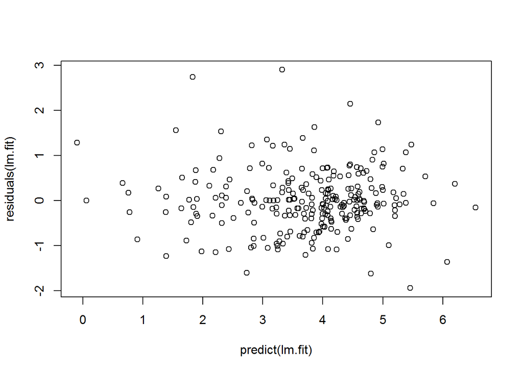

```r
plot(predict(lm.fit), residuals(lm.fit))
```

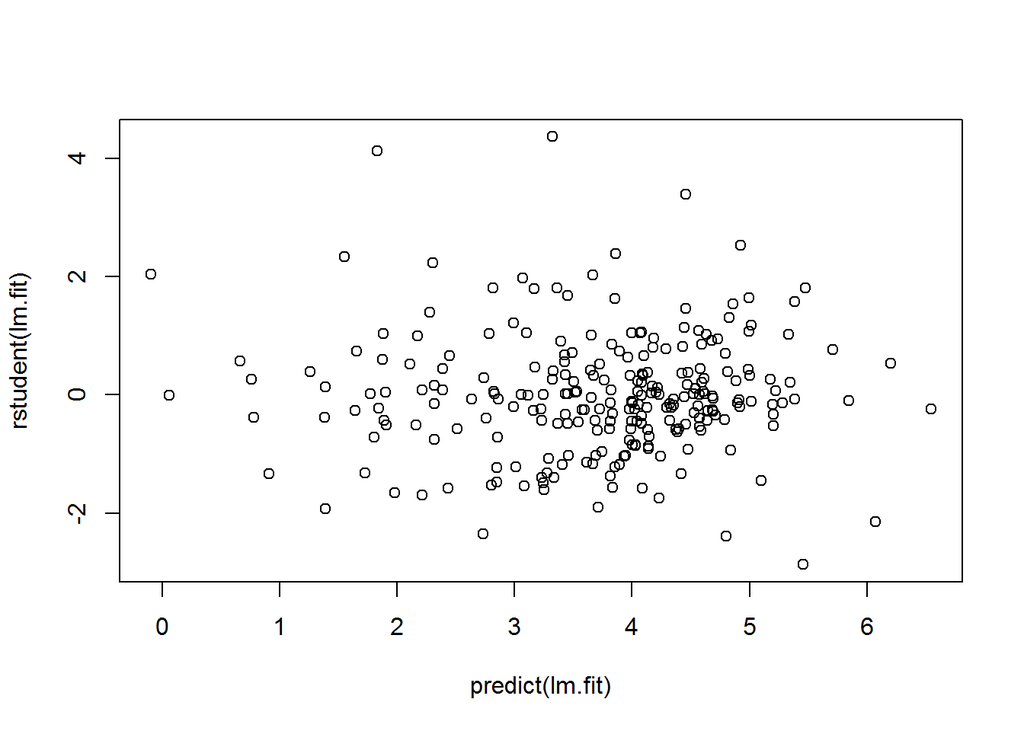

```r
plot(predict(lm.fit), rstudent(lm.fit))
```

Plot residuals versus molecules to zoom in the performance of the model:

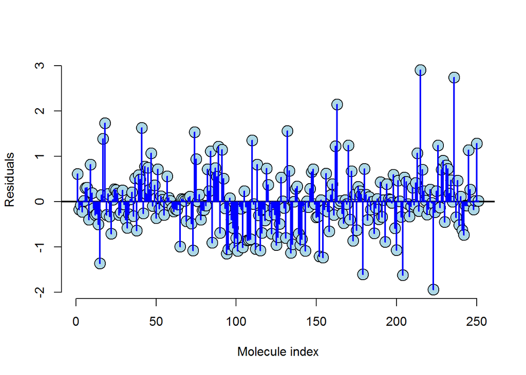

```r
e <- resid(lm.fit)
n <- length(e)
x <- 1:n

plot(x, e,
     xlab = "Molecule index",
     ylab = "Residuals",
     bg = "lightblue",
     col = "black", cex = 2, pch = 21,frame = FALSE)
abline(h = 0, lwd = 2)
for (i in 1 : n)
  lines(c(x[i], x[i]), c(e[i], 0), col = "blue" , lwd = 2)
```

Examining leverage values:

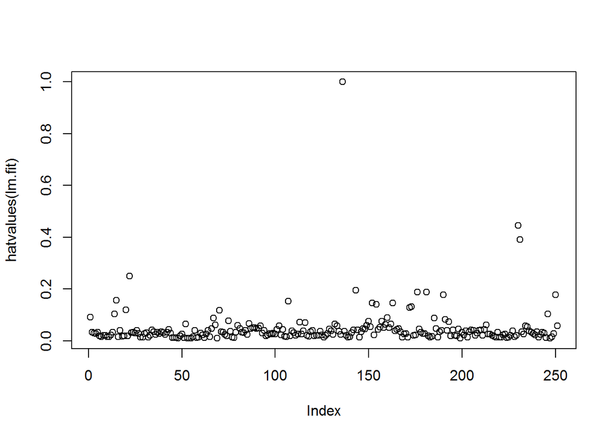

```r
plot(hatvalues(lm.fit))
```

```r
which.max(hatvalues(lm.fit))
```

```
## 170
## 136
```

```r
dfb <- data.frame(dfbetas(lm.fit))
summary(dfbetas(lm.fit)[-c(136,170),1])
```

```
##       Min.    1st Qu.     Median       Mean    3rd Qu.       Max.
## -0.3060000 -0.0148100  0.0007689  0.0001814  0.0177600  0.3420000
```

With large leverage values and dfbetas, these two molecules are exerted.

Final model:

```r
newlm <- lm(Activity~., data = training[-c(170, 136),-13])
```

Visualising the performance of the final model:

```r
p1 <- data.frame(predict(newlm, test, interval = "confidence"))
p2 <- data.frame(predict(newlm, test, interval = "prediction"))
```

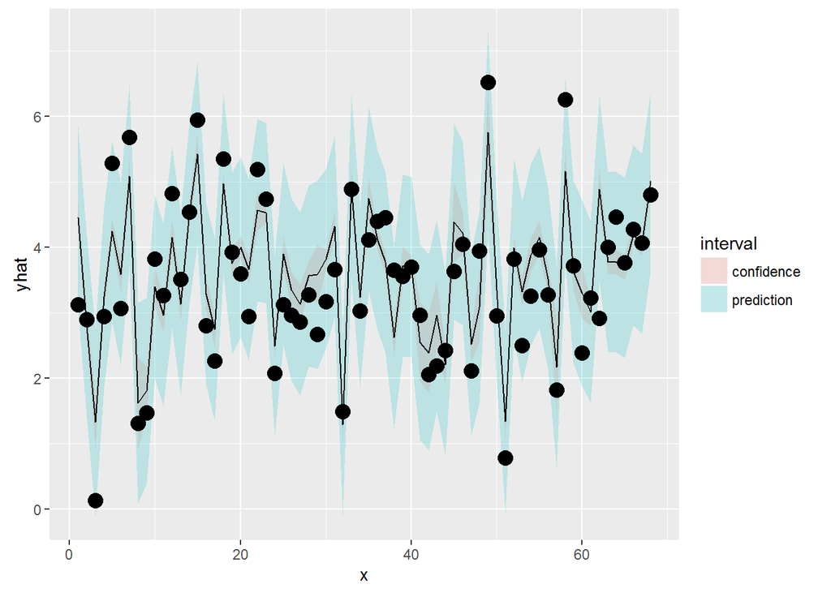

```r
p1$interval = "confidence"
p2$interval = "prediction"
p1$x = 1:nrow(test)
p1$Activity <- test$Activity
p2$x = 1:nrow(test)
p2$Activity <- test$Activity
dat = rbind(p1, p2)
names(dat)[1] = "yhat"

ggplot(dat, aes(x, yhat)) +
  geom_ribbon(aes(ymin = lwr, ymax = upr, fill = interval), alpha = 0.2) +
  geom_line() +
  geom_point(aes(x, Activity), size = 4)
```